# STAT 420: Homework 01

Fall 2020, Sahana Epari

Due: Tuesday, September 15 by 11:30 PM CT

# Assignment

## Exercise 1 (Working with Vectors)

Recall the definitions of sample mean and sample standard deviation for data $x_1, x_2, \ldots, x_n$.

$$\bar{x} = \displaystyle\frac{1}{n}\sum_{i=1}^{n}x_{i}$$

$$s = \sqrt{\frac{1}{n - 1}\sum_{i=1}^{n}(x - \bar{x})^2}$$

Consider the following vector of data.

```r
x = c(1, 1, 2, 3, 5, 8, 13, 21, 34, 55, 89, 144)
```

**(a)** Calculate the sample mean of `x` *without* the use of `mean()`, `sd()`, `sum()`, or `+`. Hint: Recall that vectors in `R` are column vectors. (Although when you display them, they often *look* like row vectors.) You may need to create a second vector, which is allowed, and should also look into the function `crossprod()`. Essentially, you need to use matrix algebra to recreate the formulas above. You may use `mean()` to check your answer.

```r
unitvector <- rep(1,length(x))
totalsum <- x %*% unitvector #cross product
mean <- totalsum/length(x)

mean
```

```
##          [,1]
## [1,] 31.33333
```

```r
mean(x) #check answer
```

```
## [1] 31.33333
```

The mean is 31.33

**(b)** Calculate the sample standard deviation of `x` *without* the use of `mean()`, `sd()`, `sum()`, or `+`. You may use `sd()` to check your answer.

```r
meanvector <- rep(mean[1,1],length(x))
a <- (x - meanvector)**2 #sum of squares
sd <- ((a %*% unitvector) * (1/(length(x)-1)))**0.5

sd
```

```
##          [,1]
## [1,] 44.48766
```

```r
sd(x) #check answer
```

```
## [1] 44.48766
```

## Exercise 2 (Vectors and Matrices)

For this exercise, you will create several vectors and matrices, as well as perform various matrix operations.

**(a)** Create five vectors `x0`, `x1`, `x2`, `x3`, and `y`. Each should have a length of 30 and store the following:

- `x0`: Each element should be the value `1`.
- `x1`: The first 30 square numbers, starting from `1` (so `1`, `4`, `9`, etc.)
- `x2`: 30 evenly spaced numbers between `0` and `1`. (Including `0` and `1`. It may help to read the documentation for `seq()`.)
- `x3`: The natural log of the integers from `1` to `30`
- `y`: The result of running the following code, after creating the other four vectors:

```r
x0 <- rep(1,30)
x1 <- (seq(1,30,1))**2
x2 <- seq(0,1,1/29)
x3 <- log(seq(1,30,1))

set.seed(114)
y  = 5 * x0 + 1 * x1 + 6 * x2 + 3 * x3 + rnorm(n = 30, mean = 0 , sd = 1)

sum(y)
```

```
## [1] 9916.469
```

Report the value returned from `sum(y)`.

**(b)** Create a matrix `X` which stores `x0`, `x1`, `x2`, and `x3` as columns of the matrix. Report the value returned from `sum(X)`.

```r
X <- cbind(x0,x1,x2,x3)
sum(X)
```

```
## [1] 9574.658
```

**(c)** Use matrix operations to create a new matrix `beta_hat` defined as follows:

$$\hat{\beta} = (X^T X)^{-1} X^T y.$$

```r
beta_hat <- solve(t(X) %*% X) %*% (t(X) %*% y)
```

Report the values stored in the matrix `beta_hat`. Note that you can use the vector `y` as if it is a $30 \times 1$ matrix.

**(d)** Your `beta_hat` should store a $4 \times 1$ matrix. That is, a matrix with $4$ rows and $1$ column. Subset this matrix to exclude the first row, then square each element and report the sum of these results.

```r
sumofsquares <- sum((as.matrix(beta_hat[-c(x0)]))**2)

sumofsquares
```

```
## [1] 87.11211
```

**(e)** Create a new variable `y_hat` which stores the result of the matrix operation,

$$\hat{y} = X \hat{\beta}.$$

The result will be a $30 \times 1$ matrix. Perform and report the result of the following operation,

$$\sum_{i = 1}^{30} (y_i - \hat{y}_i)^ 2.$$

Here you can use the matrix `y_hat` as if it is a vector. Then, $y_i$ is the $i$th element of $y$ and $\hat{y}_i$ is the $i$th element of $\hat{y}$.

```r
y_hat <- X %*% beta_hat
sumofsquaresy <- sum((y - y_hat)**2)

sumofsquaresy
```

```
## [1] 32.99999
```

## Exercise 3 (Discrete Probability)

The [2016 United States presidential election](https://en.wikipedia.org/wiki/United_States_presidential_election,_2016) has been an interesting contest. A [Fox News National Poll](http://www.foxnews.com/politics/interactive/2016/06/09/fox-news-poll-national-releas-6-16/) from June which surveyed 1004 registered voters placed former New Mexico Governor [Gary Johnson](https://en.wikipedia.org/wiki/Gary_Johnson) in third place, which is expected, however polling in the double digits at 12%. ([Third party candidates haven’t performed well in recent years. The last time a third party managed to get votes in the Electoral College was 1968.](https://en.wikipedia.org/wiki/United_States_presidential_election,_1968))

Suppose the true proportion of registered voters that support Johnson is 12% and we obtain our own random sample of 50 registered voters. Answer the follows questions as they relate to this sample of 50 voters.

```r
trueprop <- 0.12
n <- 50
```

**(a)** What is the probability that exactly 5 of the voters are Johnson supporters?

```r
dbinom(5,n,trueprop)
```

```
## [1] 0.1673818
```

**(b)** What is the probability that 10 or fewer voters are Johnson supporters?

```r
pbinom(10,n,trueprop)
```

```
## [1] 0.967502
```

**(c)** What is the probability that 37 or more voters are **not** Johnson supporters?

```r
1 - pbinom(37,n,trueprop,lower.tail = FALSE)
```

```
## [1] 1
```

**(d)** What is the probability that between 3 and 9 (inclusive) voters are Johnson supporters?

```r
sum(dbinom(3:9,n,trueprop))
```

```
## [1] 0.8779742
```

## Exercise 4 (Continuous Probability)

For this exercise, consider a random variable $X$ which is normally distributed with a mean of 120 and a standard deviation of 15. That is,

$$X \sim N\left(\mu = 120, \sigma^2 = 225\right).$$

```r
mean = 120
sd = 15
```

**(a)** Calculate $P(X < 95)$.

```r
pnorm(95,mean,sd,lower.tail = TRUE)
```

```
## [1] 0.04779035
```

**(b)** Calculate $P(X > 140)$.

```r
pnorm(140,mean,sd,lower.tail=FALSE)
```

```
## [1] 0.09121122
```

**(c)** Calculate $P(95 < X < 120)$.

```r
pnorm(120,mean,sd,lower.tail=TRUE) - pnorm(95,mean,sd,lower.tail=TRUE)
```

```
## [1] 0.4522096
```

**(d)** Find $q$ such that $P(X < q) = 0.05$.

```r
qnorm(0.05,mean,sd,lower.tail=TRUE)
```

```
## [1] 95.3272
```

**(e)** Find $q$ such that $P(X > q) = 0.10$.

```r
qnorm(0.10,mean,sd,lower.tail = FALSE)
```

```
## [1] 139.2233
```

## Exercise 5 (Packages, Plotting)

For this exercise, we will use the `diabetes` dataset from the `faraway` package.

**(a)** Install and load the `faraway` package. **Do not** include the install command in your .Rmd file. (If you do it will install the package every time you knit your file.) **Do** include the command to load the package into your environment.

```r
library(faraway)
data(diabetes)
```

**(b)** How many observations are in this dataset? How many variables?

```r
nrow(diabetes)
```

```
## [1] 403
```

```r
ncol(diabetes)
```

```
## [1] 19
```

**(c)** What are the names of the variables in this dataset?

```r
names(diabetes)
```

```
##  [1] "id"       "chol"     "stab.glu" "hdl"      "ratio"    "glyhb"
##  [7] "location" "age"      "gender"   "height"   "weight"   "frame"
## [13] "bp.1s"    "bp.1d"    "bp.2s"    "bp.2d"    "waist"    "hip"
## [19] "time.ppn"
```

**(d)** What is the mean [HDL](https://en.wikipedia.org/wiki/High-density_lipoprotein) level (High Density Lipoprotein) of individuals in this sample?

```r
mean(diabetes$hdl,na.rm=TRUE)
```

```
## [1] 50.44527
```

**(e)** What is the standard deviation total cholesterol of individuals in this sample?

```r
sd(diabetes$chol,na.rm=TRUE)
```

```
## [1] 44.44556
```

**(f)** What is the range of ages of individuals in this sample?

```r
range(diabetes$age)
```

```
## [1] 19 92
```

**(g)** What is the mean HDL of females in this sample?

```r
females <- diabetes[diabetes$gender == "female",]
mean(females$hdl,na.r=TRUE)
```

```
## [1] 52.11111
```

**(h)** Create a scatterplot of HDL (y-axis) vs weight (x-axis). Use a non-default color for the points. (Also, be sure to give the plot a title and label the axes appropriately.) Based on the scatterplot, does there seem to be a relationship between the two variables? Briefly explain.

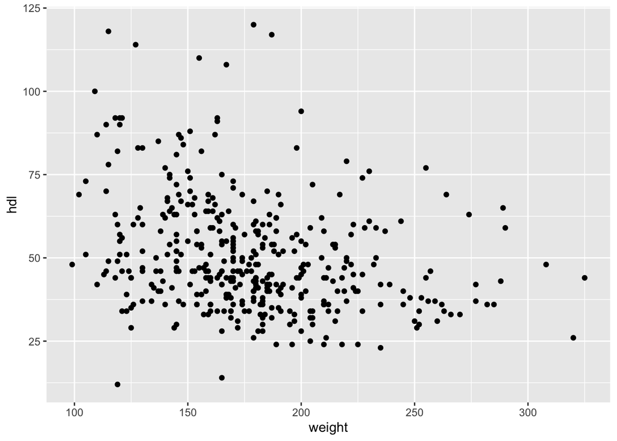

```r
library(ggplot2)
ggplot(diabetes, aes(x=weight,y=hdl)) + geom_point()
```

There seems to be a very small negative correlation between hdl and weight, but nothing major.

**(i)** Create a scatterplot of total cholesterol (y-axis) vs weight (x-axis). Use a non-default color for the points. (Also, be sure to give the plot a title and label the axes appropriately.) Based on the scatterplot, does there seem to be a relationship between the two variables? Briefly explain.

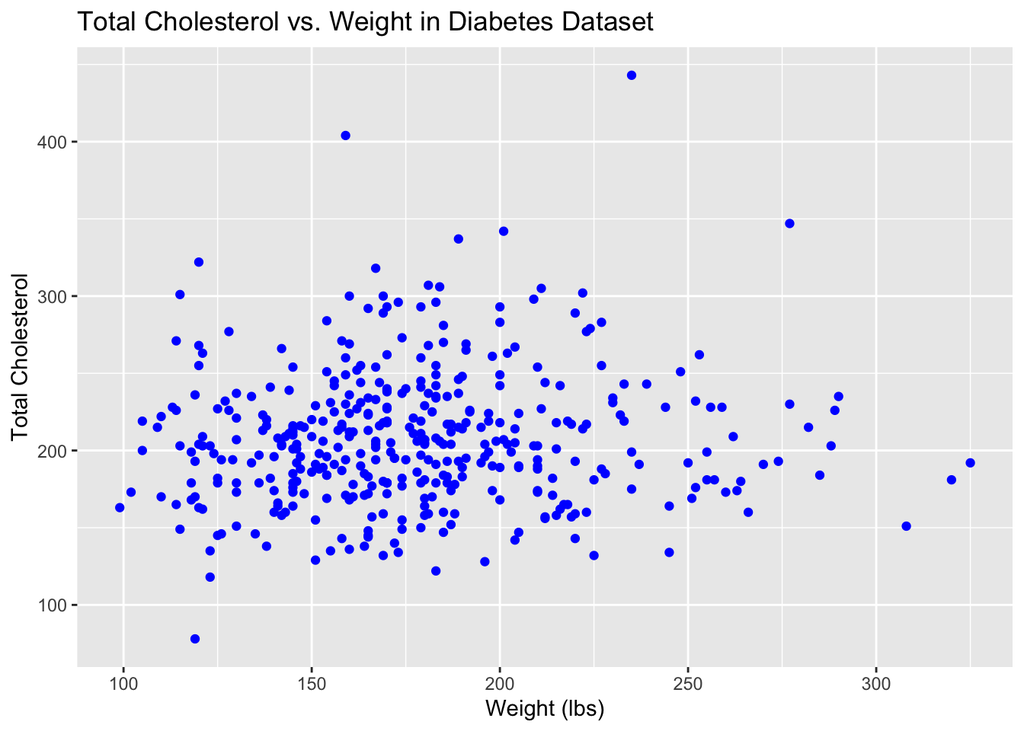

```r
ggplot(diabetes,aes(x=weight,y=chol)) + geom_point(colour = "blue") + labs(x="Weight (lbs)",y="Total Cholesterol", title="Total Cholesterol vs. Weight in Diabetes Dataset")
```

There doesn’t seem to be any correlation between weight and cholesterol. Most data points seem to be hovering around total chol = 200.

## Exercise 6 (Importing Data, Plotting)

For this exercise we will use the data stored in `nutrition.csv`. It contains the nutritional values per serving size for a large variety of foods as calculated by the USDA. It is a cleaned version totaling 5138 observations and is current as of September 2015.

The variables in the dataset are:

- `ID`
- `Desc` - Short description of food
- `Water` - in grams
- `Calories` - in kcal
- `Protein` - in grams
- `Fat` - in grams
- `Carbs` - Carbohydrates, in grams
- `Fiber` - in grams
- `Sugar` - in grams
- `Calcium` - in milligrams
- `Potassium` - in milligrams
- `Sodium` - in milligrams
- `VitaminC` - Vitamin C, in milligrams
- `Chol` - Cholesterol, in milligrams
- `Portion` - Description of standard serving size used in analysis

```r
nutrition <- read.csv("nutrition.csv")
```

**(a)** Create a histogram of `Calories`. Do not modify `R`’s default bin selection. Make the plot presentable. Describe the shape of the histogram. Do you notice anything unusual?

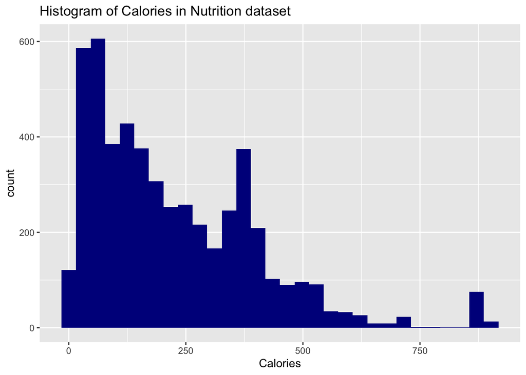

```r
ggplot(nutrition,aes(Calories)) + geom_histogram(fill="dark blue") + labs(title="Histogram of Calories in Nutrition dataset")
```

**(b)** Create a scatterplot of calories (y-axis) vs protein (x-axis). Make the plot presentable. Do you notice any trends? Do you think that knowing only the protein content of a food, you could make a good prediction of the calories in the food?

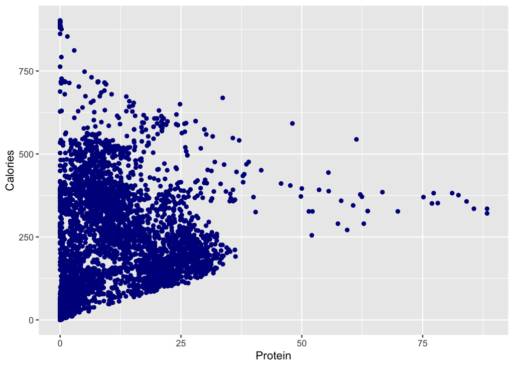

```r
ggplot(nutrition,aes(x=Protein,y=Calories)) + geom_point(color = "dark blue")
```

Protein does not seem to be a good predictor for Calories, especially in the lower protein range could mean a very wide range of foods.

**(c)** Create a scatterplot of `Calories` (y-axis) vs `4 * Protein + 4 * Carbs + 9 * Fat + 2 * Fiber` (x-axis). Make the plot presentable. You will either need to add a new variable to the data frame, or, use the `I()` function in your formula in the call to `plot()`. If you are at all familiar with nutrition, you may realize that this formula calculates the calorie count based on the protein, carbohydrate, and fat values. You’d expect then that the result here is a straight line. Is it? If not, can you think of any reasons why it is not?

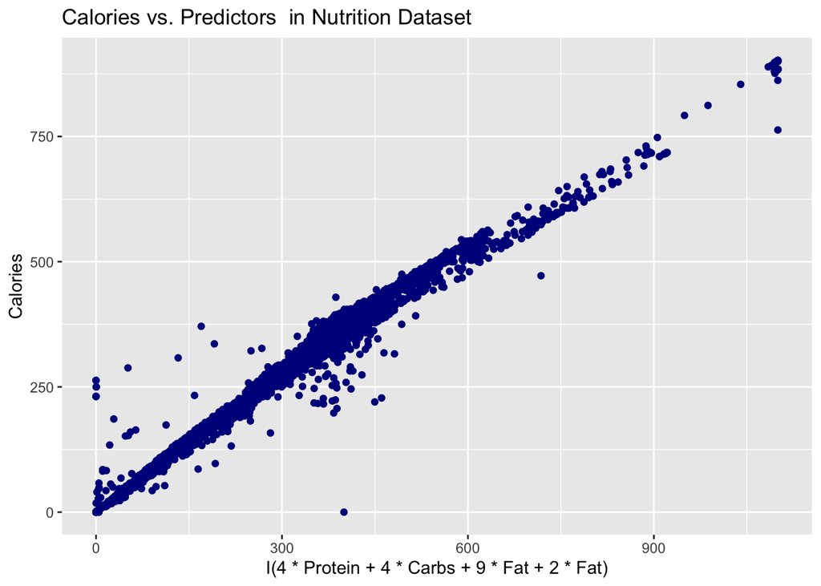

```r
ggplot(nutrition,aes(x=I(4*Protein + 4*Carbs + 9*Fat + 2*Fat), y=Calories)) + geom_point(color="dark blue") + labs(title = "Calories vs. Predictors  in Nutrition Dataset")
```

It seems that using all of these predictors can pretty accurately determine the calories in a certain food, however there is always data that doesn’t abide by this rule.